# Economic Growth

Session 1

Luis F. Gómez L.

luis.gomezl@unimilitar.edu.co

Distance Learning Faculty

29 January, 2026

# Please Read Me

- Check the message **Welcome greeting** published in Announcements forum.
- Dear student please edit your profile uploading a photo where your face is clearly visible.
- If you want to participate, please fill out the following survey: **Primer corte 30% > Learning Activities > Tu opinión sobre la economía colombiana**
- This presentation is based on (Cardenas, 2020, Chapter 3)
- **Purpose**
  - Analyze the determinants of economic growth

# What is economic growth?

- Economic growth can be define as an increase in the quantity and quality of products that a society produces and consumes (Roser, 2013)
- The definition of economic growth is straightforward but this concept is extremely difficult to measure (Roser, 2013)
- Economists often measure economic growth as an increase in Gross Domestic Product per capita by applying inflation adjustments. Furthermore, if international comparisons are necessary also purchase power parity (PPP) adjustments are applied (Roser, 2013)
- From the long-term perspective of social history economic growth is a recent phenomena (Roser, 2013)
- For data related to economic growth from a long-term perspective check out (Bolt & Van Zanden, 2024b) and (Bolt & Van Zanden, 2024a)

# Economic growth from a long-term perspective

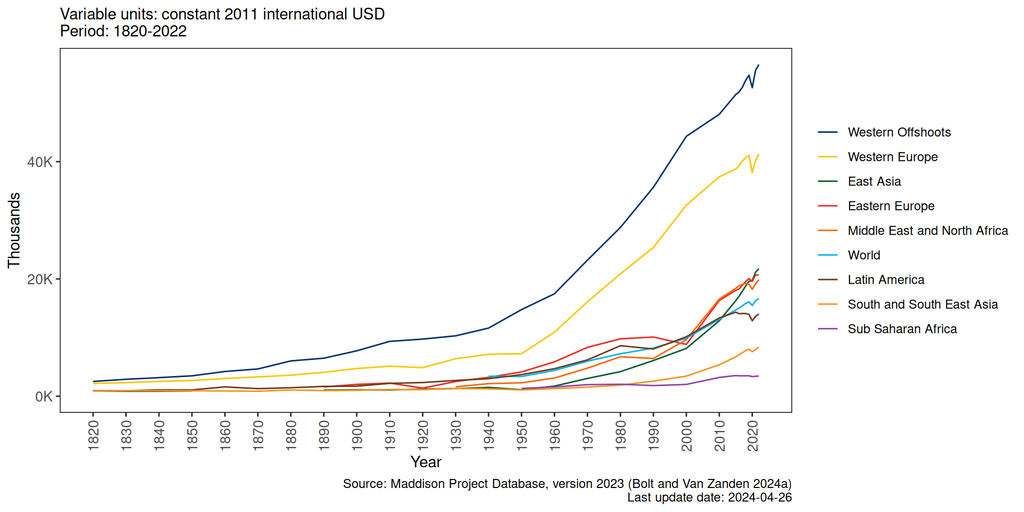

# Economic growth paths

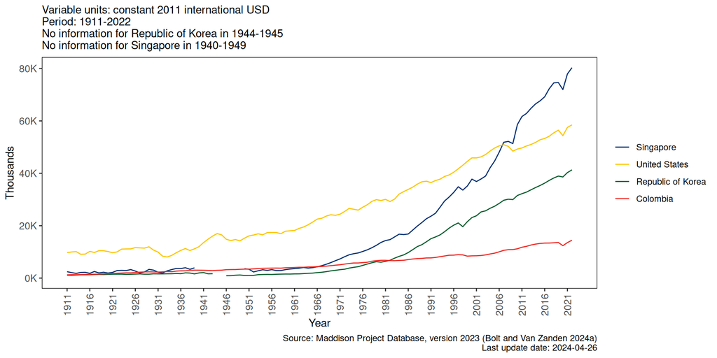

Figure 2: GDP per-capita purchasing power parity, Colombia, USA, Republic of Korea and Singapore

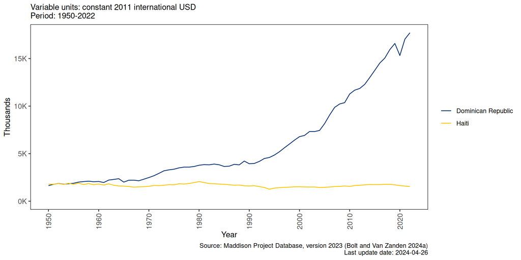

Figure 3: GDP per-capita purchasing power parity, Haiti and Dominican Republic

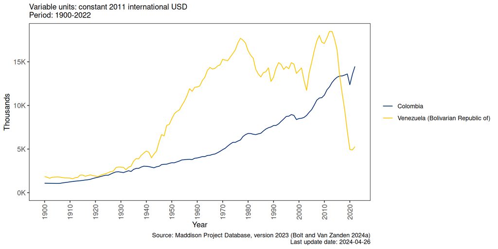

Figure 4: GDP per-capita purchasing power parity, Colombia and Venezuela

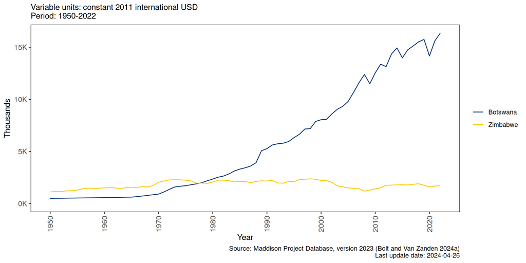

Figure 5: GDP per-capita purchasing power parity, Zimbabwe and Botswana

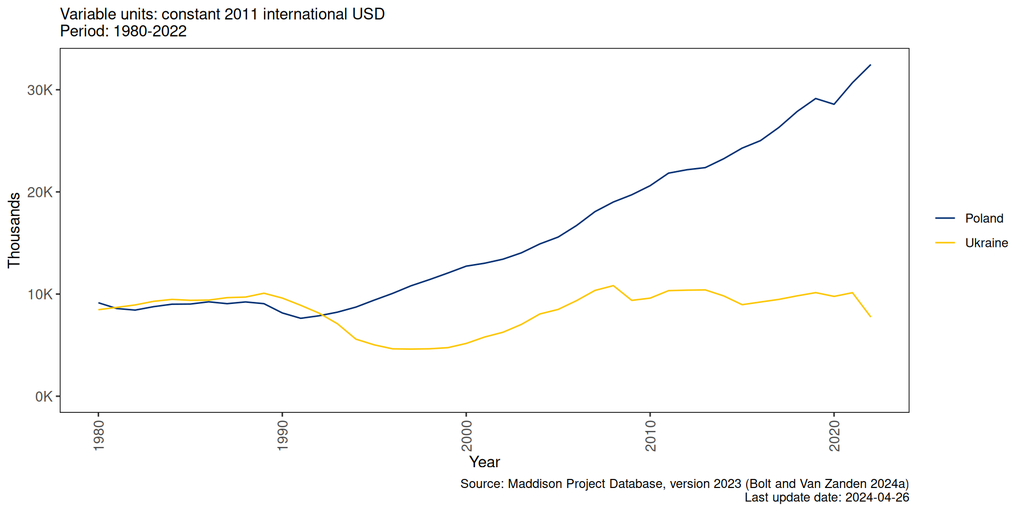

Figure 6: GDP per-capita purchasing power parity, Ukraine and Poland

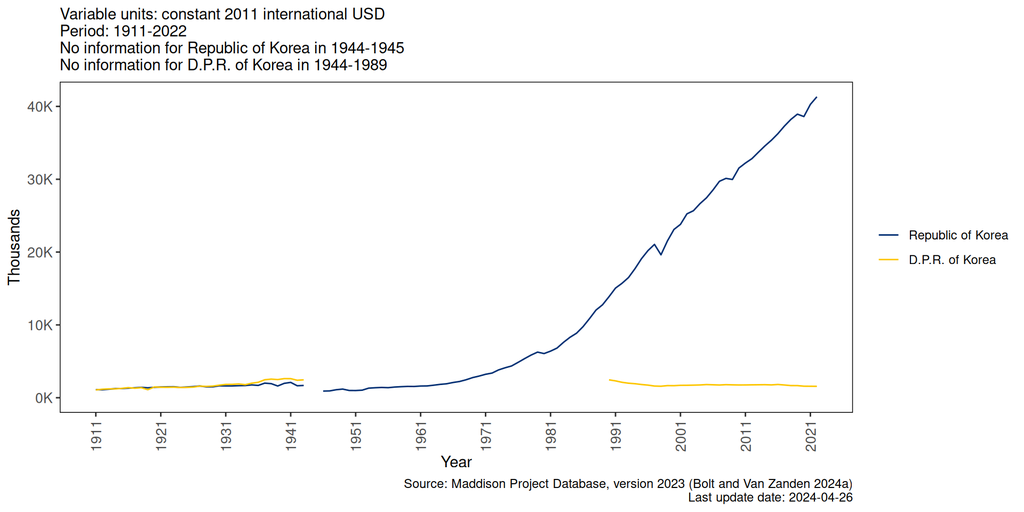

Figure 7: GDP per-capita purchasing power parity, D.P.R. of Korea and Republic of Korea

# Economic growth in images

[figure not shown]

(a) 1987

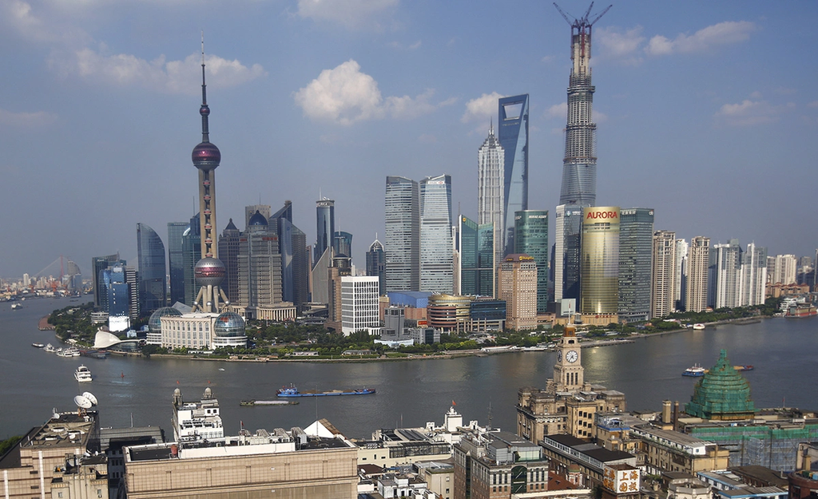

(b) 2013

Figure 8: Shanghai’s financial district of Pudong (Taylor, 2013)

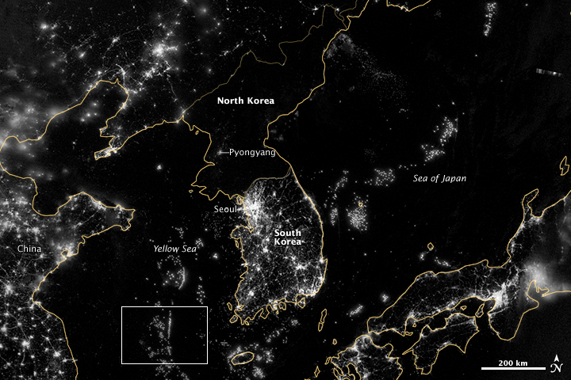

Figure 9: Korean peninsula, nocturnal luminosity: September 24, 2012 (Observatory et al., 2012)

- Google Earth Timelapse Dubai, UAE check out[^1]:
  - https://youtu.be/pjM26oRIay0
- Explore about Timelapse at: https://earthengine.google.com/timelapse
  - Urban growth
    - Dalian, Liaoning, China
    - Las Vegas, Nevada, USA

# Acknowledgments

- To my family that supports me
- To the taxpayers of Colombia and the [**UMNG students**](https://www.umng.edu.co/estudiante) who pay my salary
- To the [**Business Science**](https://www.business-science.io/) and [**R4DS Online Learning**](https://www.rfordatasci.com/) communities where I learn [**R**](https://www.r-project.org/about.html) and [**$\pi$-thon**](https://www.python.org/about/)
- To the [**R Core Team**](https://www.r-project.org/contributors.html), the creators of [**RStudio IDE**](https://posit.co/download/rstudio-desktop/), [**Positron**](https://positron.posit.co/), [**Quarto**](https://quarto.org/) and the authors and maintainers of the packages [**tidyverse**](https://CRAN.R-project.org/package=tidyverse), [**readxl**](https://CRAN.R-project.org/package=readxl), [**scales**](https://CRAN.R-project.org/package=scales) and [**tinytex**](https://CRAN.R-project.org/package=tinytex) for allowing me to access these tools without paying for a license

# References

Bolt, J., & Van Zanden, J. L. (2024a). *Maddison Project Database 2023*. DataverseNL. https://doi.org/10.34894/INZBF2

Bolt, J., & Van Zanden, J. L. (2024b). Maddison‐style estimates of the evolution of the world economy: A new 2023 update. *Journal of Economic Surveys*, 1–41. https://doi.org/10.1111/joes.12618

Cardenas, M. (2020). *Introducción a la Economía Colombiana* (4th ed.). Alfaomega.

Observatory, N. E., Allen, J. A., & Simmon, R. (2012). *Korea and the Yellow Sea*. https://earthobservatory.nasa.gov/images/79796/korea-and-the-yellow-sea

Roser, M. (2013). Economic Growth. *Our World in Data*. https://ourworldindata.org/economic-growth

Taylor, A. (2013). *26 Years of Growth: Shanghai Then and Now - The Atlantic*. https://www.theatlantic.com/photo/2013/08/26-years-of-growth-shanghai-then-and-now/100569/

## Footnotes

[^1]: Timelapse is a global, zoomable video that lets you see how the Earth has changed over the past 32 years